# TRATAMIENTO DE DATOS CON R

Joaquín Planelles Romero e Isabel Padilla Sánchez

octubre de 2021

# data.table

[figure not shown]

Llegamos a la última unidad del curso. Si lo que esperabais era encontrar algo así como un resumen de los contenidos tratados en las unidades anteriores… ¡Error! Lo que vamos a hacer es cambiar de tercio y meternos en algo nuevo.

En el momento de escribir estas líneas hay en CRAN (el repositorio oficial de paquetes de R) un total de 17.884 librerías disponibles. En promedio, cada día se añaden o actualizan más de 50 librerías. Con esto, lo que queremos decir es que R es mucho más que `tidyverse`. Hay multitud de paquetes diseñados para las distintas fases del ciclo del dato. Y como no podía ser menos, también hay distintas opciones para la fase de tratamiento/manipulación de datos que ha sido objeto de este curso.

En esta última unidad vamos a hacer referencia a otro paquete muy popular de R llamado `data.table`. Igual que `tidyr` y `dplyr`, es un paquete pensado para tratamiento de datos. Al no pertenecer a `tidyverse`, la sintaxis/filosofía de trabajo de este paquete es distinta a la que venimos utilizando en las unidades previas. En esta unidad tan solo aspiramos a (1) que sepáis que existe (2) presentar los principales aspectos de la sintaxis `data.table`.

La primera versión de `data.table` se lanzó en 2004, mucho tiempo antes de que se desarrollaran las librerías de `tidyverse`. Si el rasgo característico de `tidyverse` es la sencillez y legibilidad del código resultante, el foco de `data.table` ha estado siempre en la rapidez del proceso. La sintaxis del código resultante no es tan intuitiva, pero si diseñas bien tu código el proceso resultante será rápido. Para ello, el programa no usa data.frames/tibbles sino una estructura de datos propia, llamada igual que la librería, ‘data.table’.

Recordad que para que la librería esté operativa, primero tendréis que tenerla instalada y tendréis que cargarla en la sesión de trabajo.

# Sintaxis data.table

La librería `data.table` tiene una sintaxis más próxima a la sintaxis original del paquete base de R. Por ello, se utilizarán extensivamente los corchetes. Como siempre, la chuleta resulta de lo más ilustrativa a este respecto:

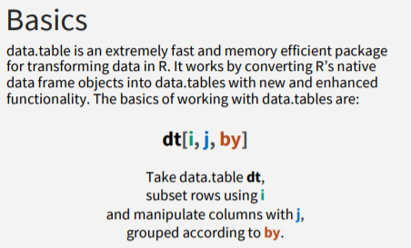

Lo primero que subrayan en el recuadro es precisamente que el foco de ´data.table´ está en la velocidad/eficiencia del proceso. En segundo lugar, nos muestran cómo se deben programar las consultas en una estructura de datos data.table. Así, el primer elemento (i), que encontrarás dentro del corchete antes de la primera coma, indicará la operación que pretendes realizar por filas, típicamente filtrar casos. El segundo elemento (j) lo encontrarás justo después de la primera coma y te indicará las operaciones que quieres hacer por columnas (seleccionar columnas y crear nuevas variables). Finalmente, si tu consulta implica agregar/resumir casos, puedes incluir un tercer elemento después de la segunda coma, en el que indicarás cuál es la variable de agrupación.

### Datos y ejemplos prácticos

Este es el típico caso en el que un script vale más que mil palabras. En lo que sigue, vamos a ilustrar esta forma de trabajar mediante algunos ejemplos, que compararemos con los equivalentes `tidyverse`. Para ello, vamos a recuperar un conjunto de datos que ya hemos utilizado anteriormente en este curso: los datos relativos a los contenidos (películas y series) disponibles en la plataforma Netflix. Descargamos los datos en el data.frame ‘Netflix’, del que crearemos una copia con estructura data.table a la que denominaremos ‘Netflix_dt’:

```r
Netflix <- read_csv('https://raw.githubusercontent.com/rfordatascience/tidytuesday/master/data/2021/2021-04-20/netflix_titles.csv')

#Con el siguiente comando creamos una copia del conjunto de datos, pero con estructura 'data.table' y con la muletilla '_dt' en el nombre:
Netflix_dt <- setDT(Netflix)
```

En la tabla adjunta se describe el contenido de esta tabla de datos:

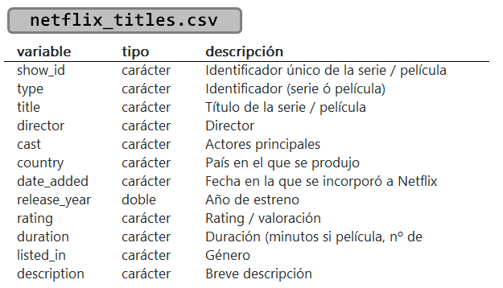

#### **Ejemplo 1 - filtrar casos**

A continuación un ejemplo de cómo se filtrarían algunas filas. Vamos a ver cómo seleccionaríamos los contenidos de Netflix producidos en España:

```r
# Con tidyverse
  Netflix_Esp <- Netflix %>% filter(country=='Spain')

# Con data.table
  Netflix_dt_Esp <- Netflix_dt[country=='Spain']
```

#### **Ejemplo 2 - seleccionar columnas**

A continuación un ejemplo de cómo seleccionaríamos determinadas columnas (concretamente las columnas ‘title’ y ‘duration’). De este modo, también mostraremos otra característica de la sintaxis de data.table: para comunicar una lista (en nuestro caso los nombres de las dos variables que queremos seleccionar) se lo indicamos con la estructura `.(elementos)`. Así, los distintos elementos de la lista se introducen dentro del paréntesis, separados por comas y el paréntesis va precedido de un punto:

```r
# Con tidyverse
  Netflix_Esp <- Netflix %>% select(title, duration)

# Con data.table
  Netflix_dt_Esp <- Netflix_dt[, .(title,duration)]
```

#### **Ejemplo 3 - crear una nueva variable**

Siguiendo con el ejemplo de Netflix, vamos a crear una nueva variable que nos informe, para los contenidos de tipo película (‘Movie’) de si ese contenido es reciente (fue emitido por primera vez en 2019, 2020 ó 2021) o por el contrario es más antiguo.

Este ejemplo nos va a permitir introducir otras dos características de la sintaxis `data.table` (1) el operador `:=`, es el que te va a permitir asignar nombre a la nueva variable (2) cuando quieres hacer algo parecido a una tubería con `data.table`, lo que tienes que hacer es concatenar corchetes: [operación1][operación2]

```r
# Con tidyverse
  Netflix_Esp <- Netflix %>% filter(type=='Movie') %>% mutate(reciente=if_else(release_year >= 2019, 1, 0))

# Con data.table
  Netflix_dt_Esp <- Netflix_dt[type=='Movie'][,reciente := ifelse(release_year >= 2019, 1, 0)]
```

#### **Ejemplo 4 - agrupar**

Finalmente, mostraremos cómo se agrupa con `data.table`. Para ello, vamos a calcular cuántas películas se han producido en cada país

```r
# Con tidyverse
  Netflix_Esp <- Netflix %>% filter(type=='Movie') %>% group_by(country) %>% summarise(num_pelis=n()) %>% arrange(desc(num_pelis))

# Con data.table
  Netflix_dt_Esp <- Netflix_dt[type=='Movie'][, .N, by=country][order(-N)]
```

# dtplyr

[figure not shown]

Conscientes de la popularidad y funcionalidades de `data.table`, desde `tidyverse` (que son muy pillos) también han desarrollado un traductor a código `data.table`.

De nuevo, como hemos visto con las bases de datos, podrás escribir tu código con la sintaxis que ya conoces y usar el traductor, denominado `dtplyr` para lanzar de forma ciega un código con sintaxis `data.table`, que para algunas operaciones será más rápido, o te permitirá utilizar funcionalidades de otras librerías desarrolladas para estructuras de datos data.table.

Para usar el paquete, como siempre, lo primero será asegurarte de que has instalado la librería (`install.packages('dtplyr')`) y que la has cargado en tu sesión de trabajo (`library(dtplyr)`). Una vez instalada y cargada la librería, tan sólo tendrás que escribir tu código partiendo de una estructura de datos data.table. R entenderá automáticamente que lo que quieres es que transforme tu código `dplyr` en código `data.table`.

Veámoslo con un ejemplo. El conjunto de datos que hemos denominado ‘Netflix_dt’ tiene la estructura de data.table. Así que ¿Qué pasa si escribimos código ´dplyr´ partiendo de este conjunto de datos? Lo vamos a mostrar, calculando el número de series que se han producido en cada país. Fijaos en que al pedirle que nos muestre lo que ha hecho (`print(Ejemplo_dtplyr)`), el programa nos informa del código ha utilizado para traducir nuestra consulta y después nos muestra los resultados. Como podréis comprobar, se trata de una forma muy sencilla de acceder a las ventajas de data.table (velocidad de procesamiento), sin necesidad de ser un experto en esa sintaxis, que resulta menos intuitiva, con todos esos puntos, comas y corchetes.

```r
Ejemplo_dtplyr <- Netflix_dt %>% filter(type=='TV Show') %>% group_by(country) %>% summarise(num_pelis=n()) %>% arrange(desc(num_pelis))
print(Ejemplo_dtplyr)
```

```
## Source: local data table [184 x 2]
## Call:   `_DT5`[type == "TV Show"][, .(num_pelis = .N), keyby = .(country)][order(desc(num_pelis))]
##
##   country        num_pelis
##   <chr>              <int>
## 1 United States        705
## 2 <NA>                 277
## 3 United Kingdom       204
## 4 Japan                157
## 5 South Korea          147
## 6 India                 71
## # ... with 178 more rows
##
## # Use as.data.table()/as.data.frame()/as_tibble() to access results
```

# Preguntas de auto-evaluación

El objetivo de las siguientes preguntas es que podáis auto-evaluar si habéis adquirido los conocimientos. Encontraréis las respuestas en la pestaña de soluciones.

Para la resolución de algunos de estos ejercicios es necesario utilizar los ficheros planos del censo de 2011 que os hemos facilitado.

- **Pregunta 1**. data.table
  1. Es una librería de R
  2. Es una librería de tidyverse
  3. Es una librería de SQL
  4. Es una librería de libros
- **Pregunta 2**. dtplyr
  1. Es una librería de R
  2. Es una librería de tidyverse
  3. Es una librería de SQL
  4. Es una librería de libros
- **Pregunta 3**. Con los datos del data.frame ‘DATOS_HP’, que venimos utilizando a lo largo del curso y que contiene información del Censo de 2011 para las personas residentes en Andalucía ¿qué código de `data.table` utilizarías para filtrar a los residentes en el municipio de Sevilla (código INE ‘41091’)?
  1. Pregunta3 <- DATOS_HP[CPRO==‘41’ & CMUN==‘091’]
  2. Pregunta3 <- setDT(DATOS_HP)[CPRO==‘41’ & CMUN==‘091’]
  3. Pregunta3 <- DATOS_HP %>% [CPRO==‘41’ & CMUN==‘091’]
  4. Pregunta3 <- setDT(DATOS_HP) %>% [CPRO==‘41’ & CMUN==‘091’]
- **Pregunta 4**. Con los datos del data.frame ‘DATOS_HP’, que venimos utilizando a lo largo del curso y que contiene información del Censo de 2011 para las personas residentes en Andalucía ¿qué código de `data.table` utilizarías para filtrar a los residentes en el municipio de Sevilla (código INE ‘41091’) y seleccionar para cada uno de ellos las variables sexo, edad y factor de elevación (FACTOR)?
  1. Pregunta4 <- DATOS_HP[CPRO==‘41’ & CMUN==‘091’,.(SEXO,EDAD,FACTOR)]
  2. Pregunta4 <- setDT(DATOS_HP)[CPRO==‘41’ & CMUN==‘091’,.(SEXO,EDAD,FACTOR)]
  3. Pregunta4 <- setDT(DATOS_HP)[CPRO==‘41’ & CMUN==‘091’][,.(SEXO,EDAD,FACTOR)]
  4. Las respuestas B y C son correctas
- **Pregunta 5**. De nuevo, con los datos del Censo 2011 y utilizando código `data.table` ¿Cuántos hombres y cuántas mujeres de 44 años residían en la provincia de Sevilla en ese momento?
  1. 16.838 hombres y 16.009 mujeres
  2. 18.638 hombres y 18.609 mujeres
  3. 16.009 hombres y 16.838 mujeres
  4. 18.609 hombres y 18.638 mujeres

# Soluciones

A continuación se muestran, marcadas y en rojo, las soluciones a las preguntas de auto-evaluación

- **Pregunta 1**. data.table
  1. **Es una librería de R**
  2. Es una librería de tidyverse
  3. Es una librería de SQL
  4. Es una librería de libros
- **Pregunta 2**. dtplyr
  1. **Es una librería de R**
  2. **Es una librería de tidyverse**
  3. Es una librería de SQL
  4. Es una librería de libros

  **Nota a soluciones Pregunta 2**: Las dos son ciertas
- **Pregunta 3**. Con los datos del data.frame ‘DATOS_HP’, que venimos utilizando a lo largo del curso y que contiene información del Censo de 2011 para las personas residentes en Andalucía ¿qué código de `data.table` utilizarías para filtrar a los residentes en el municipio de Sevilla (código INE ‘41091’)?
  1. Pregunta3 <- DATOS_HP[CPRO==‘41’ & CMUN==‘091’]
  2. **Pregunta3 <- setDT(DATOS_HP)[CPRO==‘41’ & CMUN==‘091’]**
  3. Pregunta3 <- DATOS_HP %>% [CPRO==‘41’ & CMUN==‘091’]
  4. Pregunta3 <- setDT(DATOS_HP) %>% [CPRO==‘41’ & CMUN==‘091’]

  **Nota a soluciones Pregunta 3**:

  Para que funcione la librería `data.table` es impepinable que los datos de partida tengan la estructura data.table. Lo bueno, es que con la función `setDT()` podemos transformar fácilmente cualquier data.frame en un data.table.
- **Pregunta 4**. Con los datos del data.frame ‘DATOS_HP’, que venimos utilizando a lo largo del curso y que contiene información del Censo de 2011 para las personas residentes en Andalucía ¿qué código de `data.table` utilizarías para filtrar a los residentes en el municipio de Sevilla (código INE ‘41091’) y seleccionar para cada uno de ellos las variables sexo, edad y factor de elevación (FACTOR)?
  1. Pregunta4 <- DATOS_HP[CPRO==‘41’ & CMUN==‘091’,.(SEXO,EDAD,FACTOR)]
  2. Pregunta4 <- setDT(DATOS_HP)[CPRO==‘41’ & CMUN==‘091’,.(SEXO,EDAD,FACTOR)]
  3. Pregunta4 <- setDT(DATOS_HP)[CPRO==‘41’ & CMUN==‘091’][,.(SEXO,EDAD,FACTOR)]
  4. **Las respuestas B y C son correctas**
- **Pregunta 5**. De nuevo, con los datos del Censo 2011 y utilizando código `data.table` ¿Cuántos hombres y cuántas mujeres de 44 años residían en la provincia de Sevilla en ese momento?
  1. 16.838 hombres y 16.009 mujeres
  2. 18.638 hombres y 18.609 mujeres
  3. **16.009 hombres y 16.838 mujeres**
  4. 18.609 hombres y 18.638 mujeres

  **En concreto, hemos utilizado el siguiente código para obtener el resultado:**

  ```r
  Pregunta5 <- setDT(DATOS_HP)[CPRO == '41' & EDAD=='044'][, .(Num = sum(as.numeric(FACTOR))), by = .(SEXO)]
  ```